# RPS10 DADS Experiment

2024-05-21

```r
knitr::opts_chunk$set(echo = TRUE)
knitr::opts_knit$set(root.dir = "~/DADS")
library(phyloseq); packageVersion("phyloseq")
```

```
## [1] '1.50.0'
```

```r
library(ggplot2); packageVersion("ggplot2")
```

```
## [1] '3.5.1'
```

```r
library(readr); packageVersion("readr")
```

```
## [1] '2.1.5'
```

```r
library(purrr); packageVersion("purrr")
```

```
## [1] '1.0.4'
```

```r
library(furrr); packageVersion("furrr")
```

```
## [1] '0.3.1'
```

```r
library(dplyr); packageVersion("dplyr")
```

```
## [1] '1.1.4'
```

```r
library(stringr); packageVersion("stringr")
```

```
## [1] '1.5.1'
```

```r
library(metacoder); packageVersion("metacoder")
```

```
## [1] '0.3.8'
```

```r
library(data.table); packageVersion("data.table")
```

```
## [1] '1.16.4'
```

```r
library(Biostrings); packageVersion("Biostrings")
```

```
## [1] '2.74.1'
```

```r
library(vegan);packageVersion("vegan")
```

```
## [1] '2.6.10'
```

```r
library(agricolae);packageVersion("agricolae")
```

```
## [1] '1.3.7'
```

```r
library(magrittr);packageVersion("magrittr")
```

```
## [1] '2.0.3'
```

```r
library(data.table);packageVersion("data.table")
```

```
## [1] '1.16.4'
```

```r
library(ggbeeswarm);packageVersion("ggbeeswarm")
```

```
## [1] '0.7.2'
```

```r
library(DESeq2);packageVersion("DESeq2")
```

```
## [1] '1.46.0'
```

```r
library(cowplot);packageVersion("cowplot")
```

```
## [1] '1.1.3'
```

```r
theme_set(theme_cowplot())
library(doParallel);packageVersion("doParallel")
```

```
## [1] '1.0.17'
```

```r
library(viridis);packageVersion("viridis")
```

```
## [1] '0.6.5'
```

### Load data

```r
load("Data/RPS10/filtered_data/dadsexp.RData")
load("Data/RPS10/filtered_data/dads_5asv.RData")

filtered_read_counts<-read.csv("Data/RPS10/filtered_data/RPS10_subset_track_reads_dads.csv")
summary(filtered_read_counts)
```

```
##       X                 input           filtered        denoisedF
##  Length:24          Min.   : 23998   Min.   : 10645   Min.   : 10489
##  Class :character   1st Qu.: 36716   1st Qu.: 23482   1st Qu.: 23415
##  Mode  :character   Median : 94920   Median : 62708   Median : 62522
##                     Mean   : 89684   Mean   : 60075   Mean   : 59963
##                     3rd Qu.:116028   3rd Qu.: 82126   3rd Qu.: 81948
##                     Max.   :182463   Max.   :134696   Max.   :134636
##    denoisedR          merged          nonchim
##  Min.   : 10617   Min.   :  9247   Min.   :  8754
##  1st Qu.: 23442   1st Qu.: 22724   1st Qu.: 22195
##  Median : 62540   Median : 59516   Median : 52137
##  Mean   : 59948   Mean   : 57223   Mean   : 52991
##  3rd Qu.: 81943   3rd Qu.: 78416   3rd Qu.: 74879
##  Max.   :134421   Max.   :128616   Max.   :114265
```

### Rarefaction curve

```r
otu_data <- as(otu_table(dads_5asv.ps), "matrix")

S <- specnumber(otu_data) # observed number of species
raremax <- min(rowSums(otu_data))

pdf("Figures/RPS10/rarefaction_curve.pdf", width = 10, height = 8)
rarecurve(otu_data, step = 10, sample = raremax, col = "blue", cex = 0.6, label = TRUE, xlab = "Sequencing Depth", ylab = "Number of ASVs")
dev.off()
```

```r
# Save the plot to a PDF
pdf("Figures/RPS10/speciesaccum_curve.pdf", width = 10, height = 8)
asv_accum <- vegan::specaccum(otu_data, method = "exact")
plot(asv_accum, ci.type = "poly", col = "blue", lwd = 2, ci.lty = 0, ci.col = "lightblue", xlab = "Number of samples", ylab = "Number of Filtered ASVs")
dev.off()
```

### Bar plot agglomerated by species-using filtered dataset and facet wrapped by treatment

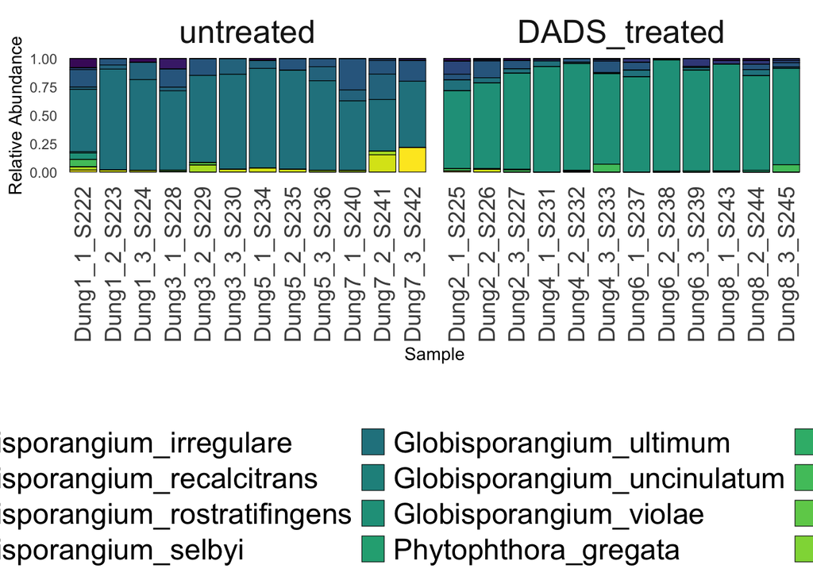

```r
RPS10data <- dads_5asv.ps %>%
  tax_glom(taxrank = "Species") %>%                     # agglomerate at Genus level
  transform_sample_counts(function(x) {x/sum(x)} ) %>% # Transform to rel. abundance
  psmelt() %>%                                         # Melt to long format
  #filter(Abundance > 0.02) %>%                       # Filter out low abundance taxa
  arrange(desc(Abundance))
                                # Sort data frame alphabetically by phylum

# Plot
abund_plot <- ggplot(RPS10data, aes(x = Sample, y = Abundance, fill = Species)) +
  geom_bar(stat = "identity", position = "stack", color = "black", size = 0.2) +
  scale_fill_viridis_d() +
  scale_color_viridis_d() +
  theme_minimal() +
  labs(
    y = "Relative Abundance",
    fill = "Species"
  ) +
  facet_grid(~factor(Treatment), scales = "free_x") +
  theme(
    axis.text.x = element_text(angle = 90, hjust = 1, vjust = 0.5, size = 14),
    panel.grid.major = element_blank(),
    panel.grid.minor = element_blank(),
    legend.position = "bottom",
    legend.text = element_text(size = 14),
    legend.title = element_text(size = 20),  # Adjust legend title size
    legend.key.size = unit(2, "lines"),  # Adjust the size of the legend color key
    strip.text = element_text(size = 20),
    strip.background = element_blank()
  ) +
  guides(
    fill = guide_legend(
      reverse = FALSE,
      keywidth = 1,
      keyheight = 1,
      title.position = "top",
      title.hjust = 3,  # Center the legend title
      label.theme = element_text(size = 18)  # Adjust the size of the legend labels
    )
  )
abund_plot
```

```r
ggsave("Figures/RPS10/relabundance_plot_treatment_relabund_species_dads.pdf", abund_plot, width = 22, height = 16)
```

### Bar plot agglomerated by species-using filtered dataset and faceted by soil

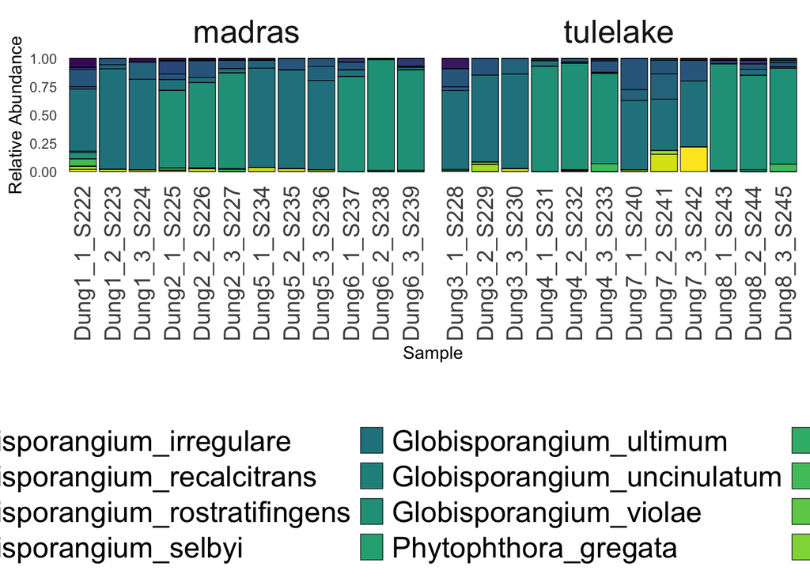

```r
RPS10data <- dads_5asv.ps %>%
  tax_glom(taxrank = "Species") %>%                     # agglomerate at Genus level
  transform_sample_counts(function(x) {x/sum(x)} ) %>% # Transform to rel. abundance
  psmelt() %>%                                         # Melt to long format
  #filter(Abundance > 0.02) %>%                       # Filter out low abundance taxa
  arrange(desc(Abundance))
                                # Sort data frame alphabetically by phylum

# Plot
abund_plot <- ggplot(RPS10data, aes(x = Sample, y = Abundance, fill = Species)) +
  geom_bar(stat = "identity", position = "stack", color = "black", size = 0.2) +
  scale_fill_viridis_d() +
  scale_color_viridis_d() +
  theme_minimal() +
  labs(
    y = "Relative Abundance",
    fill = "Species"
  ) +
  facet_grid(~factor(Soil), scales = "free_x") +
  theme(
    axis.text.x = element_text(angle = 90, hjust = 1, vjust = 0.5, size = 14),
    panel.grid.major = element_blank(),
    panel.grid.minor = element_blank(),
    legend.position = "bottom",
    legend.text = element_text(size = 14),
    legend.title = element_text(size = 20),  # Adjust legend title size
    legend.key.size = unit(2, "lines"),  # Adjust the size of the legend color key
    strip.text = element_text(size = 20),
    strip.background = element_blank()
  ) +
  guides(
    fill = guide_legend(
      reverse = FALSE,
      keywidth = 1,
      keyheight = 1,
      title.position = "top",
      title.hjust = 3,  # Center the legend title
      label.theme = element_text(size = 18)  # Adjust the size of the legend labels
    )
  )

abund_plot
```

```r
ggsave("Figures/RPS10/relabundance_plot_soil_relabund_species_dads.pdf", abund_plot, width = 22, height = 16)
```

### Bar plot agglomerated by species-using filtered dataset and faceted by incubation

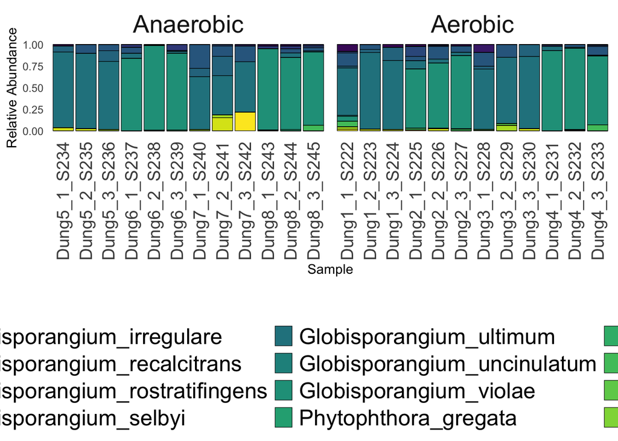

```r
RPS10data <- dads_5asv.ps %>%
  tax_glom(taxrank = "Species") %>%                     # agglomerate at Genus level
  transform_sample_counts(function(x) {x/sum(x)} ) %>% # Transform to rel. abundance
  psmelt() %>%                                         # Melt to long format
  #filter(Abundance > 0.02) %>%                       # Filter out low abundance taxa
  arrange(desc(Abundance))
                                # Sort data frame alphabetically by phylum

# Plot
abund_plot <- ggplot(RPS10data, aes(x = Sample, y = Abundance, fill = Species)) +
  geom_bar(stat = "identity", position = "stack", color = "black", size = 0.2) +
  scale_fill_viridis_d() +
  scale_color_viridis_d() +
  theme_minimal() +
  labs(
    y = "Relative Abundance",
    fill = "Species"
  ) +
  facet_grid(~factor(Incubation, labels = c("Anaerobic", "Aerobic")), scales = "free_x") +
  theme(
    axis.text.x = element_text(angle = 90, hjust = 1, vjust = 0.5, size = 14),
    panel.grid.major = element_blank(),
    panel.grid.minor = element_blank(),
    legend.position = "bottom",
    legend.text = element_text(size = 14),
    legend.title = element_text(size = 20),  # Adjust legend title size
    legend.key.size = unit(2, "lines"),  # Adjust the size of the legend color key
    strip.text = element_text(size = 20),
    strip.background = element_blank()
  ) +
  guides(
    fill = guide_legend(
      reverse = FALSE,
      keywidth = 1,
      keyheight = 1,
      title.position = "top",
      title.hjust = 3,  # Center the legend title
      label.theme = element_text(size = 18)  # Adjust the size of the legend labels
    )
  )

abund_plot
```

```r
ggsave("Figures/RPS10/relabundance_plot_incubation_relabund_species_dads.pdf", abund_plot, width = 22, height = 16)
```

### Let’s look top taxa

```r
new_names <- sapply(strsplit(dads_5asv.ps@sam_data$Sample_nameRps10, "-"), `[`, 1)

# Rename the Sample_nameRps10 column
dads_5asv.ps@sam_data$Sample_nameRps10 <- new_names

top40 <- names(sort(taxa_sums(dads_5asv.ps), decreasing=TRUE))[1:40]
ps.top40 <- transform_sample_counts(dads_5asv.ps, function(OTU) OTU/sum(OTU))
ps.top40<- tax_glom(ps.top40, taxrank = "Species")
ps.top40 <- prune_taxa(top40, ps.top40)

pdf("Figures/RPS10/top40_species_dads.pdf", width = 34, height = 20)
plot_bar(ps.top40, x="Sample_nameRps10", fill="Species") + facet_wrap(~Treatment, scales="free_x")
dev.off()
```

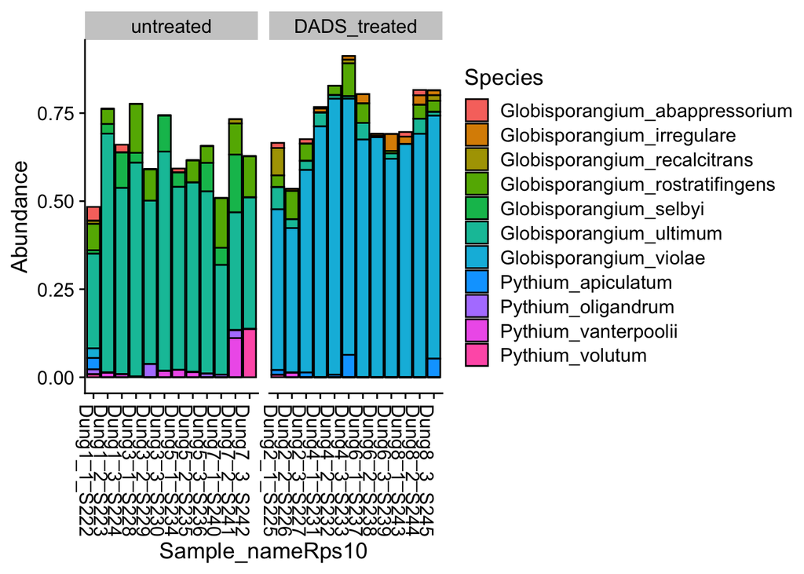

```r
plot_bar(ps.top40, x="Sample_nameRps10", fill="Species") + facet_wrap(~Treatment, scales="free_x")
```

```r
data <-
  dads_5asv.ps %>%
  tax_glom("Species") %>%
  psmelt() %>%
  as_tibble()

data_summed <- data %>%
  filter(Abundance > 0) %>%
  group_by(Kingdom, Phylum, Class, Order, Family, Genus, Species) %>%
  summarise(Abundance = sum(Abundance),
            Prevalence = n_distinct(Sample)) %>%
  ungroup() %>%
  mutate(Total_Abundance = sum(Abundance)) %>%
  mutate(Percentage = 100*(Abundance / Total_Abundance))
```

```
## 'Family', 'Genus'. You can override using the `.groups` argument.
```

```r
write.csv(data_summed, file="Results/RPS10/mostabundanttaxa_abundance_dads_species.csv",row.names = TRUE)

data <-
  dads_5asv.ps %>%
  tax_glom("Genus") %>%
  psmelt() %>%
  as_tibble()

data_summed <- data %>%
  filter(Abundance > 0) %>%
  group_by(Kingdom, Phylum, Class, Order, Family, Genus) %>%
  summarise(Abundance = sum(Abundance),
            Prevalence = n_distinct(Sample)) %>%
  ungroup() %>%
  mutate(Total_Abundance = sum(Abundance)) %>%
  mutate(Percentage = 100*(Abundance / Total_Abundance))
```

```
## 'Family'. You can override using the `.groups` argument.
```

```r
write.csv(data_summed, file="Results/RPS10/mostabundanttaxa_abundance_dads_genus.csv",row.names = TRUE)


data1 <-
  dads_5asv.ps %>%
  tax_glom("Species") %>%
  transform_sample_counts(function(x) {x/sum(x)} ) %>%
  psmelt() %>%
  as_tibble()

data_summed1 <- data1 %>%
  filter(Abundance > 0) %>%
  group_by(Treatment, Kingdom, Phylum, Class, Order, Family, Genus, Species) %>%
  summarise(Abundance = sum(Abundance),
            Prevalence = n_distinct(Sample))
```

```
## 'Order', 'Family', 'Genus'. You can override using the `.groups` argument.
```

```r
write.csv(data_summed1, file="Results/RPS10/mostabundanttaxa_relativeabundance_untreatedtreated_dads.csv",row.names = TRUE)

data2 <-
  dads_5asv.ps %>%
  tax_glom("Species") %>%
  psmelt() %>%
  as_tibble()

# Calculate percentages
data_summed2 <- data2 %>%
  filter(Abundance > 0) %>%
  group_by(Treatment, Kingdom, Phylum, Class, Order, Family, Genus, Species) %>%
  summarise(Abundance = sum(Abundance),
            Prevalence = n_distinct(Sample))
```

```
## 'Order', 'Family', 'Genus'. You can override using the `.groups` argument.
```

```r
write.csv(data_summed2, file="Results/RPS10/mostabundanttaxa_untreatedtreated_dads.csv",row.names = TRUE)
```

### Let’s normalize our data in preparation for beta diversity analyses

```r
#Prune ASVs not present in least 5 times (across one more more samples)
#dads_5asv.ps<- phyloseq::prune_taxa(taxa_sums(dads.ps) > 5, dads.ps)
sdt = data.table::data.table(as(sample_data(dads_5asv.ps), "data.frame"),
                 TotalReads = sample_sums(dads_5asv.ps), keep.rownames = TRUE)
min_reads<-min(sdt$TotalReads)

rarefied.ps <- rarefy_even_depth(dads_5asv.ps, sample.size = min_reads, rngseed = 100)
```

```
## `set.seed(100)` was used to initialize repeatable random subsampling.
```

```
## Please record this for your records so others can reproduce.
```

```
## Try `set.seed(100); .Random.seed` for the full vector
```

```
## ...
```

```
## 6OTUs were removed because they are no longer
## present in any sample after random subsampling
```

```
## ...
```

```r
#Relative abundance
strat_rel.ps<-transform_sample_counts(dads_5asv.ps, function(x) x / sum(x))
```

### Alpha diversity-use non-normalized or pruned data

Let’s start with t test as point of comparison with anova analysis

```r
set.seed(1)
AD <- estimate_richness(dads.ps, measures = c("Observed", "InvSimpson", "Shannon"))
rownames(AD) <- gsub("\\.", "-", rownames(AD))

# Combine richness estimates with sample metadata
AD <- cbind(AD, sample_data(dads.ps)[row.names(AD), c("Treatment", "Incubation", "Soil")])

# Convert to data.table and keep row names as a column
AD <- data.table(AD, keep.rownames = TRUE)

# Reshape the data frame
AD <- melt(AD, id.vars = c('rn', c("Treatment", "Incubation", "Soil")))

# Now conduct t-tests (assuming you have appropriate factors)
factors <- c("Treatment", "Incubation", "Soil")
# Iterate through each factor
ttest_list <- list()

# Iterate through each factor
for (factor_name in factors) {
  # Initialize an empty data.table to store t-test results for each alpha diversity measure
  ttest <- data.table(alpha_index = character(), pvalue = numeric())

  # Iterate through each alpha diversity measure
  for (alphad in c("InvSimpson", "Shannon", "Observed")) {
    # Perform t-test
    ttest_res <- t.test(value ~ get(factor_name), data = AD[variable == alphad], var.equal = TRUE)

    # Extract p-value from t-test results and store it in the data.table
    p_value <- ttest_res$p.value
    ttest <- rbind(ttest, data.table(alpha_index = alphad, pvalue = p_value))
  }

  # Add t-test results for the current factor to the list
  ttest_list[[factor_name]] <- ttest
}

# Print t-test results
for (factor_name in factors) {
  cat(paste("T-Test Results for Factor:", factor_name), "\n")
  print(knitr::kable(ttest_list[[factor_name]], format = "markdown"))
  cat("\n")
}
```

```
## T-Test Results for Factor: Treatment
##
##
## |alpha_index |    pvalue|
## |:-----------|---------:|
## |InvSimpson  | 0.1801800|
## |Shannon     | 0.1658637|
## |Observed    | 0.6746773|
##
## T-Test Results for Factor: Incubation
##
##
## |alpha_index |    pvalue|
## |:-----------|---------:|
## |InvSimpson  | 0.2448877|
## |Shannon     | 0.5013381|
## |Observed    | 0.3359010|
##
## T-Test Results for Factor: Soil
##
##
## |alpha_index |    pvalue|
## |:-----------|---------:|
## |InvSimpson  | 0.8397675|
## |Shannon     | 0.4412708|
## |Observed    | 0.9090346|
```

### Let’s no proceed with ANOVA analyses and then compile our alpha diversity stats

```r
# Initialize an empty data.table to store combined ANOVA results for all factors
set.seed(1)
anova_list <- list()

factors2 <- c("Treatment", "Incubation", "Soil")

# Initialize a vector to store factor names for which a plot has been created
plotted_factors <- character()


final_anova_table <- data.table(factor_name = character(), alpha_index = character(), pvalue = numeric(), df_between = numeric(), df_within = numeric(), ss_between = numeric(), ss_within = numeric(), ms_between = numeric(), ms_within = numeric(), F_value = numeric())

for (factor_name in factors2) {
  # Initialize an empty data.table to store ANOVA results for each alpha diversity measure
  anova <- data.table(factor_name = character(), alpha_index = character(), pvalue = numeric(), df_between = numeric(), df_within = numeric(), ss_between = numeric(), ss_within = numeric(), ms_between = numeric(), ms_within = numeric(), F_value = numeric())

  # Iterate through each alpha diversity measure
  for (alphad in c("Observed","InvSimpson", "Shannon")) {
    # Perform ANOVA
    anova_res <- aov(value ~ get(factor_name), data = AD[variable == alphad])

    # Extract relevant statistics from ANOVA results
    anova_summary <- summary(anova_res)

    # Extract p-value from ANOVA results
    p_value <- anova_summary[[1]]$`Pr(>F)`[1]

    # Extract other statistics
    df_between <- anova_summary[[1]]$"Df"[1]
    df_within <- anova_summary[[1]]$"Df"[2]
    ss_between <- anova_summary[[1]]$"Sum Sq"[1]
    ss_within <- anova_summary[[1]]$"Sum Sq"[2]
    ms_between <- anova_summary[[1]]$"Mean Sq"[1]
    ms_within <- anova_summary[[1]]$"Mean Sq"[2]
    F_value <- anova_summary[[1]]$"F value"[1]

    # Store statistics in the data.table
    anova <- rbind(anova, data.table(factor_name = factor_name, alpha_index = alphad, pvalue = p_value, df_between = df_between, df_within = df_within, ss_between = ss_between, ss_within = ss_within, ms_between = ms_between, ms_within = ms_within, F_value = F_value))
  }

  # Append ANOVA results for the current factor to the final table
  final_anova_table <- rbind(final_anova_table, anova)
}

# Print final ANOVA table
print(knitr::kable(final_anova_table, format = "markdown"))
```

```
##
##
## |factor_name |alpha_index |    pvalue| df_between| df_within| ss_between|  ss_within| ms_between|  ms_within|   F_value|
## |:-----------|:-----------|---------:|----------:|---------:|----------:|----------:|----------:|----------:|---------:|
## |Treatment   |Observed    | 0.6746773|          1|        22|  5.0416667| 612.916667|  5.0416667| 27.8598485| 0.1809653|
## |Treatment   |InvSimpson  | 0.1801800|          1|        22|  3.7424376|  42.971595|  3.7424376|  1.9532543| 1.9160012|
## |Treatment   |Shannon     | 0.1658637|          1|        22|  0.1788457|   1.915560|  0.1788457|  0.0870709| 2.0540236|
## |Incubation  |Observed    | 0.3359010|          1|        22| 26.0416667| 591.916667| 26.0416667| 26.9053030| 0.9679009|
## |Incubation  |InvSimpson  | 0.2448877|          1|        22|  2.8464962|  43.867536|  2.8464962|  1.9939789| 1.4275458|
## |Incubation  |Shannon     | 0.5013381|          1|        22|  0.0435680|   2.050837|  0.0435680|  0.0932199| 0.4673682|
## |Soil        |Observed    | 0.9090346|          1|        22|  0.3750000| 617.583333|  0.3750000| 28.0719697| 0.0133585|
## |Soil        |InvSimpson  | 0.8397675|          1|        22|  0.0887157|  46.625317|  0.0887157|  2.1193326| 0.0418602|
## |Soil        |Shannon     | 0.4412708|          1|        22|  0.0569568|   2.037448|  0.0569568|  0.0926113| 0.6150088|
```

```r
write.csv(final_anova_table, "Results/RPS10/final_anova_table_dads.csv", row.names = FALSE)
```

### Let’s make faceted boxplots for our alpha diversity analyses

```r
# Estimate alpha diversity
set.seed(1)
AD <- estimate_richness(dads.ps, measures = c("Observed", "InvSimpson", "Shannon"))
```

[figure not shown]

```r
rownames(AD) <- gsub("\\.", "-", rownames(AD))

# Combine richness estimates with sample metadata
AD <- cbind(AD, sample_data(dads_5asv.ps)[rownames(AD), c("Treatment", "Soil", "Incubation")])


variables <- c("Treatment", "Soil", "Incubation")


# Create an empty list to store plots
plots <- list()

# Loop through each variable and create the plot
for (variable in variables) {
  p <- plot_richness(dads.ps, x = variable, measures = c("Shannon", "InvSimpson", "Observed")) +
    geom_boxplot()
  plots[[variable]] <- p
}
# Arrange plots in a grid
plots_arrange <- gridExtra::grid.arrange(
  plots[["Treatment"]], plots[["Incubation"]], plots[["Soil"]])
```

```r
  nrow = length(variables)


# Add annotations to the top of each plot
plots_arrange_with_text <- cowplot::ggdraw() +
  cowplot::draw_plot(plots_arrange) +
  cowplot::draw_plot("Treatment", x = 0.28, y = 0.98) +
  cowplot::draw_plot("Incubation", x = 0.73, y = 0.98) +
  cowplot::draw_plot("Soil", x = 0.73, y = 0.98)
# Save the arranged plots
ggsave(plots_arrange_with_text, path = "Figures/RPS10", filename = "alpha_diversity_each_factor_dads.pdf",
       width = 12, height = 16)
```

### Let’s perform TUKEY HSD tests

```r
# Define your variables of interest
set.seed(1)
variables <- c("Treatment", "Soil", "Incubation")
measures <- c("Observed", "InvSimpson", "Shannon")

# Create an empty list to store ANOVA and Tukey's results
tukey_results <- list()

# Loop through each variable and measure
for (variable in variables) {
  for (measure in measures) {
    # Subset the data for the current variable and measure
    data_subset <- AD[, c(variable, measure)]

    # Perform ANOVA
    formula <- as.formula(paste(measure, "~ ."))
    anova_res <- aov(formula, data = data_subset)

    # Perform Tukey's post-hoc test
    tukey_result <- HSD.test(anova_res, variable)

    # Store Tukey's results
    print(tukey_result)
  }
}
```

```
## $statistics
##    MSerror Df     Mean       CV      MSD
##   27.85985 22 21.20833 24.88759 4.468851
##
## $parameters
##    test    name.t ntr StudentizedRange alpha
##   Tukey Treatment   2         2.932899  0.05
##
## $means
##              Observed      std  r       se Min Max   Q25  Q50  Q75
## DADS_treated 20.75000 5.047502 12 1.523697  10  26 19.50 21.5 24.5
## untreated    21.66667 5.499311 12 1.523697  12  29 17.75 23.5 26.0
##
## $comparison
## NULL
##
## $groups
##              Observed groups
## untreated    21.66667      a
## DADS_treated 20.75000      a
##
## attr(,"class")
## [1] "group"
## $statistics
##    MSerror Df     Mean       CV      MSD
##   1.953254 22 3.767424 37.09667 1.183276
##
## $parameters
##    test    name.t ntr StudentizedRange alpha
##   Tukey Treatment   2         2.932899  0.05
##
## $means
##              InvSimpson      std  r        se      Min      Max      Q25
## DADS_treated   3.372538 1.154624 12 0.4034491 1.820343 5.617896 2.538788
## untreated      4.162310 1.604167 12 0.4034491 2.397229 6.975982 2.947815
##                   Q50      Q75
## DADS_treated 3.018738 4.264116
## untreated    3.581388 5.710598
##
## $comparison
```

[output cut: 170 more lines]

```
## anaerobic 1.761643 0.3376678 12 0.08813809 1.187410 2.269806 1.531678 1.748162
##                Q75
## aerobic   1.993547
## anaerobic 2.009548
##
## $comparison
## NULL
##
## $groups
##            Shannon groups
## aerobic   1.846856      a
## anaerobic 1.761643      a
##
## attr(,"class")
## [1] "group"
```

### Beta diversity-PERMANOVA analysis on rarefied read counts

```r
#I used the filtered dataset (removed low abundance counts less than 2)
set.seed(1)
mapping <- as.data.frame(sample_data(rarefied.ps))

mapping2=mapping[, c("Treatment", "Soil", "Incubation")]

ASV_tables_bray <- phyloseq::distance(rarefied.ps, method = "bray")

df_metadata <- data.frame(sample_data(rarefied.ps))

df_metadata<-df_metadata[, c("Treatment", "Soil", "Incubation")]

pvals <- sapply(colnames(mapping2), function(variable){

  #Create formula for adonis()
  form1<-as.formula(paste("ASV_tables_bray", variable, sep="~"))

  res <- adonis2(form1, data = df_metadata, permutations = 9999)

  # extract pvalue from adonis output
  pval <- res$`Pr(>F)`[[1]] # we take the first p value which corresponds to the variable of interest
  return(pval)
})

#Adjust p_values with fdr correction
pval_adj <- p.adjust(pvals, method = "fdr")

#Find significant variables with lower than 0.05 for their p values
save.pval.adonis0.05_braycurtis <- pval_adj[pval_adj < 0.05]
save.pval.adonis0.05_braycurtis
```

```
## Treatment
##     3e-04
```

```r
print(pval_adj)
```

```
##  Treatment       Soil Incubation
##     0.0003     0.9223     0.9223
```

### Beta diversity-PERMANOVA analyses-ASV counts transformed (rel. abundance)

```r
#I used the filtered dataset (removed low abundance counts less than 2)
set.seed(1)
mapping <- as.data.frame(sample_data(strat_rel.ps))

mapping2=mapping[, c("Treatment", "Soil", "Incubation")]

ASV_tables_bray <- phyloseq::distance(strat_rel.ps, method = "bray")

df_metadata <- data.frame(sample_data(strat_rel.ps))

df_metadata<-df_metadata[, c("Treatment", "Soil", "Incubation")]

pvals <- sapply(colnames(mapping2), function(variable){

  #Create formula for adonis()
  form1<-as.formula(paste("ASV_tables_bray", variable, sep="~"))

  res <- adonis2(form1, data = df_metadata, permutations = 9999)

  # extract pvalue from adonis output
  pval <- res$`Pr(>F)`[[1]] # we take the first p value which corresponds to the variable of interest
  return(pval)
})

#Adjust p_values with fdr correction
pval_adj <- p.adjust(pvals, method = "fdr")

#Find significant variables with lower than 0.05 for their p values
save.pval.adonis0.05_braycurtis <- pval_adj[pval_adj < 0.05]
save.pval.adonis0.05_braycurtis
```

```
## Treatment
##     3e-04
```

```r
print(pval_adj)
```

```
##  Treatment       Soil Incubation
##     0.0003     0.9153     0.9153
```

### Compile stats

```r
# Perform PERMANOVA with interactions
set.seed(1)
res <- adonis2(ASV_tables_bray ~ Treatment*Incubation*Soil, data = df_metadata, permutations = 9999, by="terms")

# Extract data from res
res_data <- data.frame(res)
colnames(res_data)[colnames(res_data) == "Pr..F."] <- "pr_f"

# Remove the last two rows (Residual and Total)
res_data <- res_data[-c(nrow(res_data)-1, nrow(res_data)),]

# Add FDR and Bonferroni adjusted p-values
res_data$FDR_adj_p <- p.adjust(res_data$pr_f, method = "fdr")
res_data$Bonferroni_adj_p <- p.adjust(res_data$pr_f, method = "bonferroni")
res_data$Factor <- rownames(res_data)

# Reorder columns
res_data <- res_data[, c("Factor", "Df", "SumOfSqs", "R2", "F", "pr_f", "FDR_adj_p", "Bonferroni_adj_p")]
rownames(res_data) <- NULL

# Perform beta dispersion analysis for main effects
beta_disp_results <- lapply(c("Treatment", "Incubation", "Soil"), function(variable) {
  res_betadisper <- betadisper(d = ASV_tables_bray, group = df_metadata[[variable]])
  perm_test_res <- permutest(res_betadisper)
  pval_betadisper <- perm_test_res$tab$`Pr(>F)`[[1]]

  data.frame(Factor = variable, P_Value_BetaDispersion = pval_betadisper)
})

beta_disp_results_df <- do.call(rbind, beta_disp_results)

# Merge PERMANOVA results with beta dispersion results
final_results <- merge(res_data, beta_disp_results_df, by = "Factor", all.x = TRUE)

# Reorder columns
final_results <- final_results[, c("Factor", "Df", "SumOfSqs", "R2", "F", "pr_f", "FDR_adj_p", "Bonferroni_adj_p", "P_Value_BetaDispersion")]

# Print the table
print(final_results, row.names = FALSE)
```

```
##                     Factor Df   SumOfSqs          R2          F   pr_f
##                 Incubation  1 0.11376479 0.017378719  1.4402652 0.2221
##            Incubation:Soil  1 0.09429093 0.014403891  1.1937256 0.2350
##                       Soil  1 0.06238260 0.009529572  0.7897653 0.3775
##                  Treatment  1 4.71300028 0.719958342 59.6667051 0.0001
##       Treatment:Incubation  1 0.11658267 0.017809179  1.4759396 0.2209
##  Treatment:Incubation:Soil  1 0.08682382 0.013263214  1.0991918 0.2508
##             Treatment:Soil  1 0.09554690 0.014595753  1.2096262 0.2384
##  FDR_adj_p Bonferroni_adj_p P_Value_BetaDispersion
##     0.2926            1e+00                  0.288
##     0.2926            1e+00                     NA
##     0.3775            1e+00                  0.552
##     0.0007            7e-04                  0.402
##     0.2926            1e+00                     NA
##     0.2926            1e+00                     NA
##     0.2926            1e+00                     NA
```

```r
# Save results
write.csv(final_results, file = "Results/RPS10/PERMANOVA_interactions_with_betadisper.csv", row.names = FALSE)
```

### What about interactions between factors?

```r
# Calculate PERMANOVA
set.seed(1)
ASV_tables_bray <- phyloseq::distance(strat_rel.ps, method = "bray")
df_metadata <- data.frame(sample_data(strat_rel.ps))
df_metadata <- df_metadata[, c("Treatment", "Soil", "Incubation")]

# Define function to perform PERMANOVA for pairwise combinations of factors
perform_permutation <- function(factor1, factor2) {
  interaction <- paste(factor1, factor2, sep = " * ")
  res <- adonis2(ASV_tables_bray ~ ., data = df_metadata[, c(factor1, factor2)], permutations = 9999)
  return(list(interaction = interaction, p_value = res$`Pr(>F)`[[1]]))
}

# Perform pairwise comparisons between factors
significant_interactions <- sapply(names(df_metadata), function(factor1) {
  sapply(names(df_metadata), function(factor2) {
    if (factor1 != factor2) {
      perform_permutation(factor1, factor2)
    } else {
      NULL
    }
  })
}, simplify = "array")

# Filter out NULLs and combine results
significant_interactions <- significant_interactions[!sapply(significant_interactions, is.null)]

# Print significant interactions
print(significant_interactions)
```

```
## [[1]]
## [[1]]$interaction
## [1] "Treatment * Soil"
##
## [[1]]$p_value
## [1] 1e-04
##
##
## [[2]]
## [[2]]$interaction
## [1] "Treatment * Incubation"
##
## [[2]]$p_value
## [1] 1e-04
##
##
## [[3]]
## [[3]]$interaction
## [1] "Soil * Treatment"
##
## [[3]]$p_value
## [1] 1e-04
##
##
## [[4]]
## [[4]]$interaction
## [1] "Soil * Incubation"
##
## [[4]]$p_value
## [1] 0.9429
##
##
## [[5]]
## [[5]]$interaction
## [1] "Incubation * Treatment"
##
## [[5]]$p_value
## [1] 1e-04
##
##
## [[6]]
## [[6]]$interaction
## [1] "Incubation * Soil"
##
## [[6]]$p_value
## [1] 0.939
```

```r
interactions_df <- do.call(rbind.data.frame, significant_interactions)
print(significant_interactions)
```

```
## [[1]]
## [[1]]$interaction
## [1] "Treatment * Soil"
##
## [[1]]$p_value
## [1] 1e-04
##
##
## [[2]]
## [[2]]$interaction
## [1] "Treatment * Incubation"
##
## [[2]]$p_value
## [1] 1e-04
##
##
## [[3]]
## [[3]]$interaction
## [1] "Soil * Treatment"
##
## [[3]]$p_value
## [1] 1e-04
##
##
## [[4]]
## [[4]]$interaction
## [1] "Soil * Incubation"
##
## [[4]]$p_value
## [1] 0.9429
##
##
## [[5]]
## [[5]]$interaction
## [1] "Incubation * Treatment"
##
## [[5]]$p_value
## [1] 1e-04
##
##
## [[6]]
## [[6]]$interaction
## [1] "Incubation * Soil"
##
## [[6]]$p_value
## [1] 0.939
```

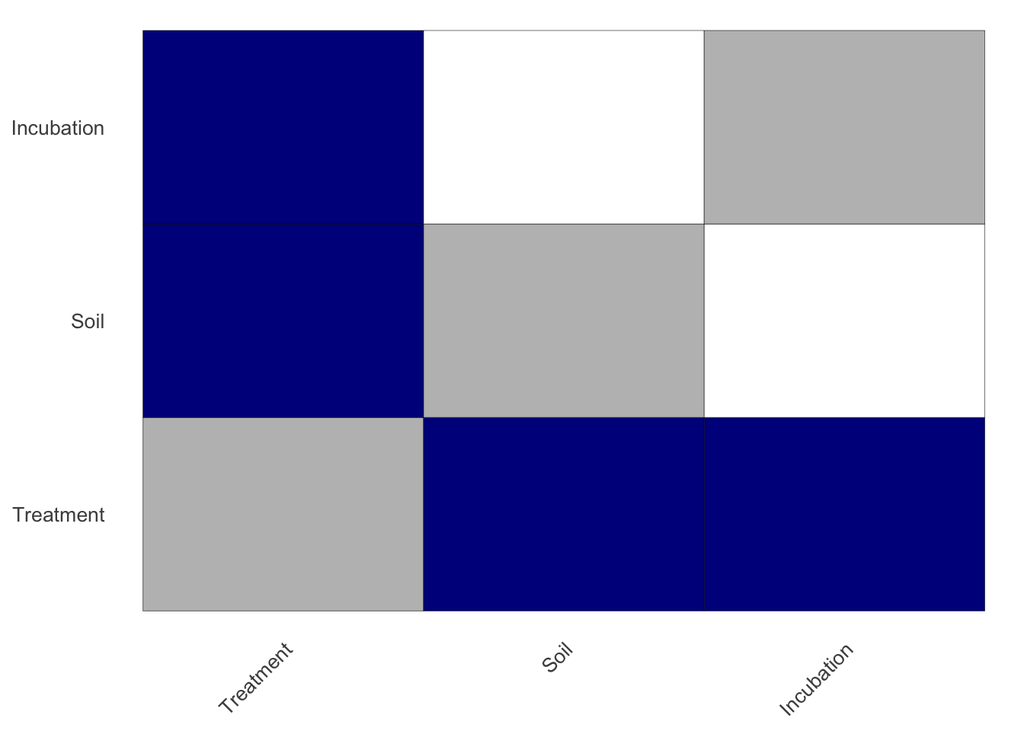

```r
interactions_df <- do.call(rbind.data.frame, significant_interactions)


adjusted_p_values <- p.adjust(interactions_df$p_value, method = "fdr")
# Add adjusted p-values to the data frame
interactions_df$p_value <- adjusted_p_values


# Extract unique factors
unique_factors <- unique(unlist(strsplit(interactions_df$interaction, " \\* ")))

# Create an empty matrix to store p-values
interaction_matrix <- matrix(NA, nrow = length(unique_factors), ncol = length(unique_factors), dimnames = list(unique_factors, unique_factors))

# Fill the matrix with p-values
for (i in 1:nrow(interactions_df)) {
  factors <- unlist(strsplit(interactions_df$interaction[i], " \\* "))
  interaction_matrix[factors[1], factors[2]] <- interactions_df$p_value[i]
  interaction_matrix[factors[2], factors[1]] <- interactions_df$p_value[i]
}

rownames(interaction_matrix) <- unique_factors
colnames(interaction_matrix) <- unique_factors


# Convert the matrix to a data frame for ggplot
interaction_df <- as.data.frame(as.table(interaction_matrix))
interaction_df <- as.data.frame(as.table(interaction_matrix))
interaction_df$color <- ifelse(is.na(interaction_df$Freq), "gray",
                               ifelse(interaction_df$Freq <= 0.01, "darkblue",
                                      ifelse(interaction_df$Freq <= 0.05, "lightblue", "white")))

# Plot heatmap with continuous color scale
heatmap <- ggplot(data = interaction_df, aes(x = Var1, y = Var2, fill = color)) +
  geom_tile(color = "black") +  # Add border for each tile
  scale_fill_manual(values = c("gray", "darkblue", "white"),
                    name = "P-value",
                    labels = c("NA", "P < 0.01", "P > 0.05"),
                    na.value = "gray") +  # Set manual color scale and legend labels
  scale_fill_identity(name = NULL) +  # Use identity scale for custom colors
  theme_minimal() +
  theme(axis.text.x = element_text(angle = 45, hjust = 1, size = 10),  # Adjust x-axis text angle and size
        axis.text.y = element_text(size = 10),  # Adjust y-axis text size
        panel.grid = element_blank(),  # Remove gridlines
        panel.border = element_blank(),  # Remove border around the plot
        axis.line = element_blank(),  # Remove axis lines
        legend.position = "bottom",  # Position legend at the bottom
        legend.direction = "horizontal",  # Horizontal legend
        legend.key.size = unit(0.5, "cm"),  # Adjust legend key size
        legend.title = element_blank(),  # Remove legend title
        legend.text = element_text(size = 8))  # Adjust legend text font size
# Assign row and column names
heatmap <- heatmap + labs(x = NULL, y = NULL)

# Print heatmap
print(heatmap)
```

```r
# Save the heatmap as a PDF file
ggsave("Figures/RPS10/permanova_interactions_heatmap_dads.pdf", plot = heatmap, width = 8, height = 6)
```

### Let’s now examine beta diversity through ordination plots

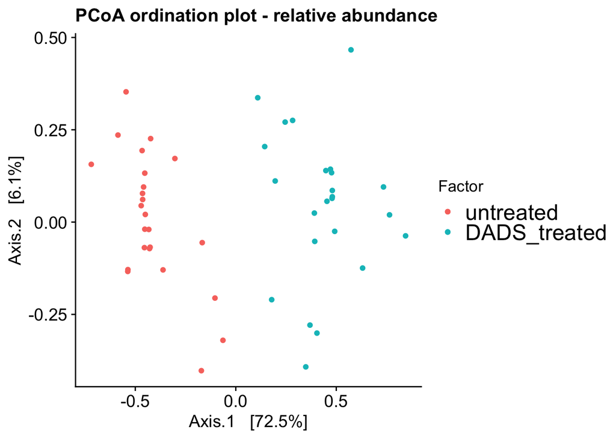

```r
devtools::install_github("ropensci/plotly")
library(plotly)
#Relative abundance
set.seed(1)
ps_PCoA = ordinate(strat_rel.ps,
                   method="PCoA",
                   distance="bray"
                   )

plot <- plot_ordination(strat_rel.ps, ps_PCoA, color = "Treatment") +
  ggtitle("PCoA ordination plot - relative abundance") +
  labs(color = "Factor") +
  theme(axis.text = element_text(size = 14),
        axis.title = element_text(size = 14),
        title = element_text(size = 13),
        legend.text = element_text(size = 18)) +
  geom_jitter(width = 0.4, height = 0.4)

plot
```

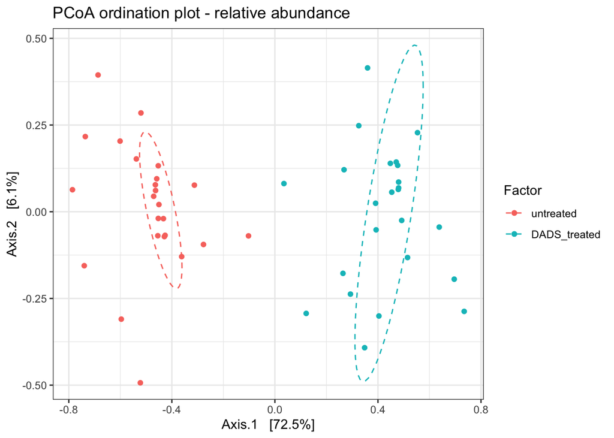

```r
plot_ellipses<-plot +
   stat_ellipse(type = "norm", linetype = 2) +
  theme_bw()

plot_ellipses
```

```r
#Export PCoA coordinates per sample
write.csv(ps_PCoA[["points"]], file="Results/RPS10/RPS10_PCoA_coordinates_persample.csv",row.names = TRUE)


res <- adonis2(ASV_tables_bray~Treatment*Incubation*Soil, data = df_metadata, permutations = 9999)
res
```

```
## Permutation test for adonis under reduced model
## Permutation: free
## Number of permutations: 9999
##
## adonis2(formula = ASV_tables_bray ~ Treatment * Incubation * Soil, data = df_metadata, permutations = 9999)
##          Df SumOfSqs      R2      F Pr(>F)
## Model     7   5.2824 0.80694 9.5536  1e-04 ***
## Residual 16   1.2638 0.19306
## Total    23   6.5462 1.00000
## ---
## Signif. codes:  0 '***' 0.001 '**' 0.01 '*' 0.05 '.' 0.1 ' ' 1
```

```r
pval=res$`Pr(>F)`[2]
pval_adj <- p.adjust(pval, method = "fdr")
print(pval_adj)
```

```
## [1] NA
```

Now, we’ll look at ordination plot (rel abundance dataset), with incubation factor

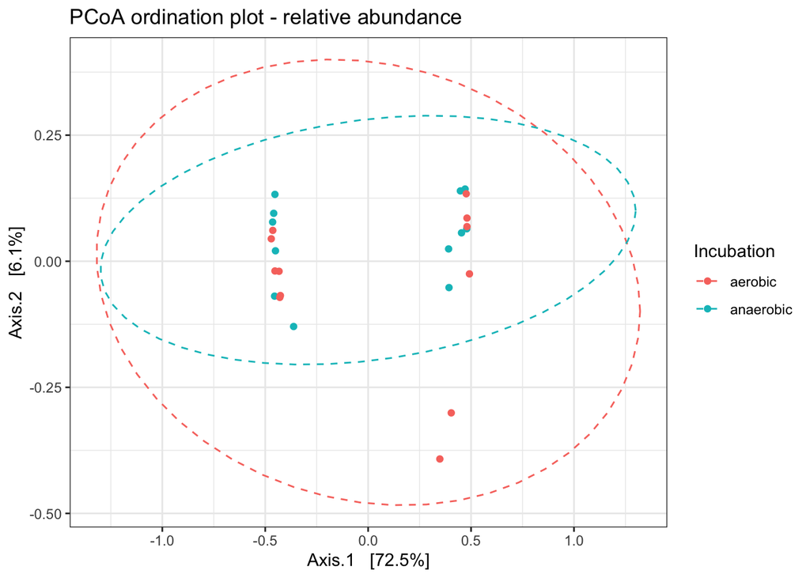

```r
#Relative abundance
set.seed(1)
ps_PCoA = ordinate(strat_rel.ps,
                   method="PCoA",
                   distance="bray")

plot<- plot_ordination(strat_rel.ps,
                         ps_PCoA,
                         labs(color = "Factor"),
                         color= "Incubation") +
  ggtitle("PCoA ordination plot - relative abundance") +
  theme(axis.text=element_text(size=14), axis.title=element_text(size=14), title =  element_text(size=13), legend.text = element_text(size = 18))
plot_ellipses<-plot +
   stat_ellipse(type = "norm", linetype = 2) +
  theme_bw()

plot_ellipses
```

Now, we’ll look at ordination plot rel abundance-with Soil factor

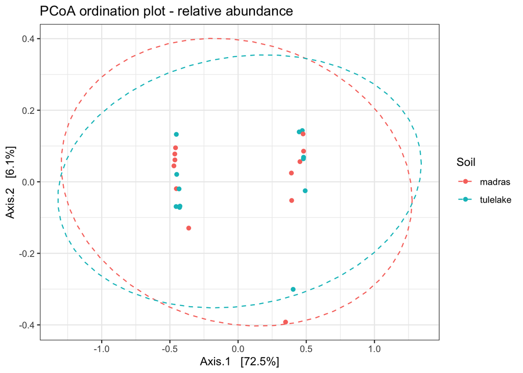

```r
#Relative abundance
set.seed(1)
ps_PCoA = ordinate(strat_rel.ps,
                   method="PCoA",
                   distance="bray")

plot<- plot_ordination(strat_rel.ps,
                         ps_PCoA,
                         labs(color = "Factor"),
                         color= "Soil") +
  ggtitle("PCoA ordination plot - relative abundance") +
  theme(axis.text=element_text(size=14), axis.title=element_text(size=14), title =  element_text(size=13), legend.text = element_text(size = 18))
plot_ellipses<-plot +
   stat_ellipse(type = "norm", linetype = 2) +
  theme_bw()

plot_ellipses
```

### Functions to prepare to do differential abundance analyses

```r
sample.data.table <- function(ps) {
  as(sample_data(ps), "data.frame") %>%
    as.data.table(keep.rownames = "Sample") %>%
    setkey(Sample) %>%
    return()
}
asv.data.table <- function(ps) {
  if (taxa_are_rows(ps)) {
    otu.mat <- t(as(otu_table(ps), "matrix"))
  } else {
    otu.mat <- as(otu_table(ps), "matrix")
  }
  return(as.data.table(otu.mat, keep.rownames = "Sample") %>% setkey(Sample))
}
cat.n <- function(x) cat(x, sep = "\n")
```

### Now we import data

```r
dads.data <- sample.data.table(dads_5asv.ps)
dads.asvs <- asv.data.table(dads_5asv.ps)
dads.asv.ids <- taxa_names(dads_5asv.ps)
dads.dt <- dads.data[dads.asvs]

#Let's adjust treatment factor so order is in line with metacoder outputs
dads_5asv.ps@sam_data$Treatment <- factor(dads_5asv.ps@sam_data$Treatment,
                                     levels = c("DADS_treated","untreated"))
```

### Conduct Wilcoxon-rank sum tests on the dads data set-treatment

```r
set.seed(1)
wilcox.tests <- lapply(dads.asv.ids, function(asv) {
  frm <- paste(asv, "~ Treatment") # this combined with the as.formula() function below makes it possible to generate formulas in R programmatically
  return(
    wilcox.test(as.formula(frm), data = dads.dt)
  )
})
```

[output not shown]

[output cut: 267 more lines]

[output not shown]

```r
dads.raw.pvals <- sapply(wilcox.tests, function(mod) {return(mod$p.value)})

dads.fdr.pvals <- p.adjust(dads.raw.pvals, method = "fdr")

paste("Significant associations:", length(dads.fdr.pvals[dads.fdr.pvals <= 0.05])) %>%
  cat.n()
```

```
## Significant associations: 18
```

```r
dads.raw.pvals <- sapply(wilcox.tests, function(mod) mod$p.value)
dads.fdr.pvals <- p.adjust(dads.raw.pvals, method = "fdr")

# Create data table of significant results
dads.wilcox.dt <- data.table(
  ASV = dads.asv.ids,
  P_Value = dads.raw.pvals,
  Adjusted_P_Value = dads.fdr.pvals
)

dads.wilcox.dt <- dads.wilcox.dt[order(Adjusted_P_Value)]

# Filter rows where Adjusted_P_Value < 0.05
dads.wilcox.dt <- dads.wilcox.dt[Adjusted_P_Value < 0.05]

# Optionally, merge taxonomic information if available
tax_table <- as.data.frame(tax_table(dads_5asv.ps))
tax_table$ASV_id <- rownames(tax_table)
dads.wilcox.dt <- merge(dads.wilcox.dt, tax_table, by.x = "ASV", by.y = "ASV_id", all.x = TRUE)

# Export to CSV
write.csv(dads.wilcox.dt, file = "Results/RPS10/wilcox_treat_vs_untreat_dads.csv", row.names = FALSE)
```

### Let’s now do a DESEQ2 analysis-treatment

```r
set.seed(1)
dads.deseq <- phyloseq_to_deseq2(dads_5asv.ps, ~ Treatment) # this function does all the heavy lifting for us to turn a phyloseq object into a DESeq2 object
#This was required so DESEQ doesn't error out (there are several approaches, but the deseq developer recommended this most recently, if going from phyloseq to deseq option)
dads.dds <- estimateSizeFactors(dads.deseq, type = 'poscounts')
dads.dds = DESeq(dads.dds)
```

```
## -- replacing outliers and refitting for 109 genes
## -- DESeq argument 'minReplicatesForReplace' = 7
## -- original counts are preserved in counts(dds)
```

```r
dads.res.dt <- results(dads.dds) %>% as.data.table(keep.rownames = "ASV")
```

```r
dads.sig.dt <- dads.res.dt[padj <= 0.05]

dads.sig.dt = cbind(as(dads.sig.dt, "data.frame"), as(tax_table(dads_5asv.ps)[dads.sig.dt$ASV, ], "matrix"))

dads.sig.dt <- dads.sig.dt %>%
  mutate(across(everything(), ~ifelse(is.na(.), "Unclassified", .)))

write.csv(dads.sig.dt, file="Results/RPS10/deseq_trt_dads.csv",row.names = TRUE)
# Now, let's create the plot
deseqplot2 <- ggplot(dads.sig.dt, aes(y = reorder(ASV, log2FoldChange), x = log2FoldChange, fill = Phylum)) +
  geom_vline(xintercept = 0.0, color = "gray", size = 0.5, linetype = "dashed") +
  geom_bar(stat = "identity", position = "dodge", width = 0.8) +
  scale_fill_viridis(discrete = TRUE, option = "D") +  # Color-blind friendly palette
  #scale_x_continuous(breaks = pretty_breaks(n = 10)) +  # Prettier x-axis breaks
  labs(x = "Log2 Fold Change",
       y = "ASV",
       title = "Differential Abundance Analysis: Treatment")
  theme_minimal() +
  theme(
    axis.text.y = element_text(size = 8),
    axis.title = element_text(face = "bold"),
    legend.position = "right",
    legend.title = element_text(face = "bold"),
    plot.title = element_text(size = 16, face = "bold"),
    plot.subtitle = element_text(size = 12),
    panel.grid.major.y = element_blank(),
    panel.grid.minor = element_blank()
  )
```

[output not shown]

[output cut: 252 more lines]

[output not shown]

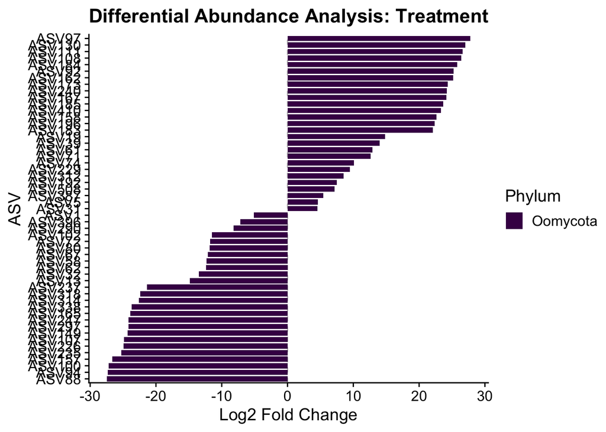

```r
# Save the plot
ggsave("Figures/RPS10/Deseq_treatment_barplot_dads_ASV.pdf", deseqplot2, width=40, height=40)

# Display the plot
print(deseqplot2)
```

### Let’s make a quick summary table of ASVs that are differentially abundant in both the Wilcoxon rank sum and DESEQ analyses-treatment

```r
# Merge the tables based on ASV
merged_table <- inner_join(dads.sig.dt, dads.wilcox.dt, by = "ASV")

# Select and rename columns in one step
final_table <- merged_table %>%
  mutate(
    deseq_pvalue = pvalue,
    deseq_padj = padj,
    wilcox_pvalue = P_Value,
    wilcox_padj = Adjusted_P_Value,
    Kingdom = Kingdom.x,
    Phylum = Phylum.x,
    Class = Class.x,
    Order = Order.x,
    Family = Family.x,
    Genus = Genus.x,
    Species = Species.x
  ) %>%
  select(
    ASV, log2FoldChange, deseq_pvalue, deseq_padj, wilcox_pvalue, wilcox_padj,
    Kingdom, Phylum, Class, Order, Family, Genus, Species
  )


# Save the final table as CSV
write.csv(final_table, "Results/RPS10/merged_deseq_trt_wilcoxon_results.csv", row.names = FALSE)
print(paste("Number of ASVs in the final table:", nrow(final_table)))
```

```
## [1] "Number of ASVs in the final table: 18"
```

### Let’s make a plot of the merged results-treatment

```r
merged_plot <- ggplot(final_table, aes(y = reorder(ASV, log2FoldChange), x = log2FoldChange, fill = Genus)) +
  geom_vline(xintercept = 0.0, color = "gray", size = 0.5, linetype = "dashed") +
  geom_bar(stat = "identity", position = "dodge", width = 0.8) +
  scale_fill_viridis(discrete = TRUE, option = "D") +  # Color-blind friendly palette
  #scale_x_continuous(breaks = pretty_breaks(n = 10)) +  # Prettier x-axis breaks
  labs(x = "Log2 Fold Change",
       y = "ASV",
       title = "Merged DESEQ2 and Wilcoxon Rank Sum Analyses-Treatment")
  theme_minimal() +
  theme(
    axis.text.y = element_text(size = 8),
    axis.title = element_text(face = "bold"),
    legend.position = "right",
    legend.title = element_text(face = "bold"),
    plot.title = element_text(size = 16, face = "bold"),
    plot.subtitle = element_text(size = 12),
    panel.grid.major.y = element_blank(),
    panel.grid.minor = element_blank()
  )
```

[output not shown]

[output cut: 252 more lines]

[output not shown]

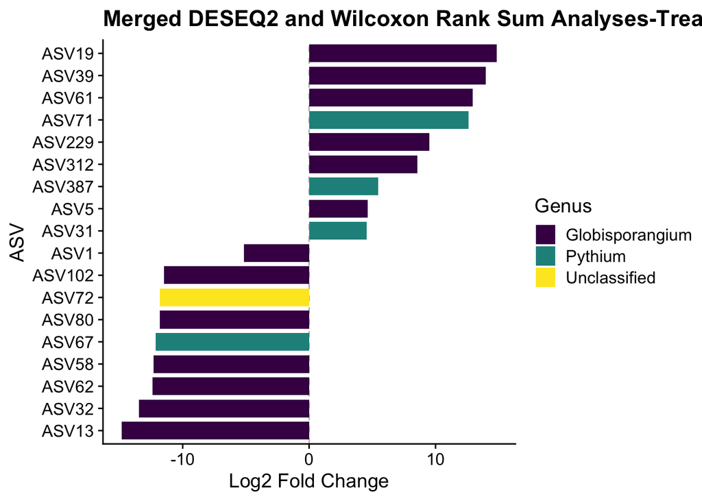

```r
# Save the plot
ggsave("Figures/RPS10/Deseq_merged_trt_barplot_dads_ASV.pdf", merged_plot, height=30, width=40)

# Display the plot
print(merged_plot)
```

### Conduct Wilcoxon-rank sum tests on the dads data set-soil

```r
set.seed(1)
wilcox.tests <- lapply(dads.asv.ids, function(asv) {
  frm <- paste(asv, "~ Soil") # this combined with the as.formula() function below makes it possible to generate formulas in R programmatically
  return(
    wilcox.test(as.formula(frm), data = dads.dt)
  )
})
```

[output not shown]

[output cut: 267 more lines]

[output not shown]

```r
dads.raw.pvals <- sapply(wilcox.tests, function(mod) {return(mod$p.value)})

dads.fdr.pvals <- p.adjust(dads.raw.pvals, method = "fdr")

paste("Significant associations:", length(dads.fdr.pvals[dads.fdr.pvals <= 0.05])) %>%
  cat.n()
```

```
## Significant associations: 0
```

```r
dads.raw.pvals <- sapply(wilcox.tests, function(mod) mod$p.value)
dads.fdr.pvals <- p.adjust(dads.raw.pvals, method = "fdr")

# Create data table of significant results
dads.wilcox.dt <- data.table(
  ASV = dads.asv.ids,
  P_Value = dads.raw.pvals,
  Adjusted_P_Value = dads.fdr.pvals
)

dads.wilcox.dt <- dads.wilcox.dt[order(Adjusted_P_Value)]

# Filter rows where Adjusted_P_Value < 0.05
dads.wilcox.dt <- dads.wilcox.dt[Adjusted_P_Value < 0.05]

# Optionally, merge taxonomic information if available
tax_table <- as.data.frame(tax_table(dads_5asv.ps))
tax_table$ASV_id <- rownames(tax_table)
dads.wilcox.dt <- merge(dads.wilcox.dt, tax_table, by.x = "ASV", by.y = "ASV_id", all.x = TRUE)

# Export to CSV
write.csv(dads.wilcox.dt, file = "Results/RPS10/wilcox_soil_dads.csv", row.names = FALSE)
```

### Let’s now do a DESEQ2 analysis-soil

```r
set.seed(1)
dads.deseq <- phyloseq_to_deseq2(dads_5asv.ps, ~ Soil) # this function does all the heavy lifting for us to turn a phyloseq object into a DESeq2 object
#This was required so DESEQ doesn't error out (there are several approaches, but the deseq developer recommended this most recently, if going from phyloseq to deseq option)
dads.dds <- estimateSizeFactors(dads.deseq, type = 'poscounts')
dads.dds = DESeq(dads.dds)
```

```
## -- note: fitType='parametric', but the dispersion trend was not well captured by the
##    function: y = a/x + b, and a local regression fit was automatically substituted.
##    specify fitType='local' or 'mean' to avoid this message next time.
```

```
## -- replacing outliers and refitting for 127 genes
## -- DESeq argument 'minReplicatesForReplace' = 7
## -- original counts are preserved in counts(dds)
```

```r
dads.res.dt <- results(dads.dds) %>% as.data.table(keep.rownames = "ASV")
```

```r
dads.sig.dt <- dads.res.dt[padj <= 0.05]

dads.sig.dt = cbind(as(dads.sig.dt, "data.frame"), as(tax_table(dads_5asv.ps)[dads.sig.dt$ASV, ], "matrix"))

dads.sig.dt <- dads.sig.dt %>%
  mutate(across(everything(), ~ifelse(is.na(.), "Unclassified", .)))

write.csv(dads.sig.dt, file="Results/RPS10/deseq_soil_dads.csv",row.names = TRUE)
# Now, let's create the plot
deseqplot2 <- ggplot(dads.sig.dt, aes(y = reorder(ASV, log2FoldChange), x = log2FoldChange, fill = Genus)) +
  geom_vline(xintercept = 0.0, color = "gray", size = 0.5, linetype = "dashed") +
  geom_bar(stat = "identity", position = "dodge", width = 0.8) +
  scale_fill_viridis(discrete = TRUE, option = "D") +  # Color-blind friendly palette
  #scale_x_continuous(breaks = pretty_breaks(n = 10)) +  # Prettier x-axis breaks
  labs(x = "Log2 Fold Change",
       y = "ASV",
       title = "Differential Abundance Analysis: Soil")
  theme_minimal() +
  theme(
    axis.text.y = element_text(size = 8),
    axis.title = element_text(face = "bold"),
    legend.position = "right",
    legend.title = element_text(face = "bold"),
    plot.title = element_text(size = 16, face = "bold"),
    plot.subtitle = element_text(size = 12),
    panel.grid.major.y = element_blank(),
    panel.grid.minor = element_blank()
  )
```

[output not shown]

[output cut: 252 more lines]

[output not shown]

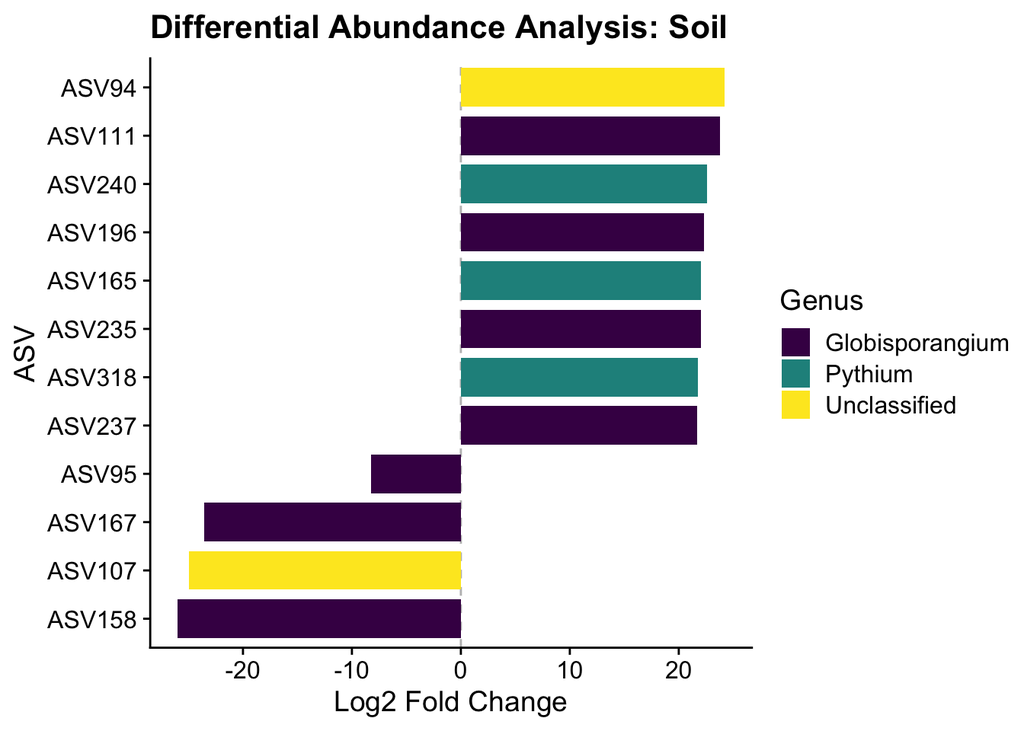

```r
# Save the plot
ggsave("Figures/RPS10/Deseq_soil_barplot_dads_ASV.pdf", deseqplot2)
# Display the plot
print(deseqplot2)
```

### Let’s make a quick summary table of ASVs that are differentially abundant in both the Wilcoxon rank sum and DESEQ analyses-soil

```r
# Merge the tables based on ASV
merged_table <- inner_join(dads.sig.dt, dads.wilcox.dt, by = "ASV")

# Select and rename columns in one step
final_table <- merged_table %>%
  mutate(
    deseq_pvalue = pvalue,
    deseq_padj = padj,
    wilcox_pvalue = P_Value,
    wilcox_padj = Adjusted_P_Value,
    Kingdom = Kingdom.x,
    Phylum = Phylum.x,
    Class = Class.x,
    Order = Order.x,
    Family = Family.x,
    Genus = Genus.x,
    Species = Species.x
  ) %>%
  select(
    ASV, log2FoldChange, deseq_pvalue, deseq_padj, wilcox_pvalue, wilcox_padj,
    Kingdom, Phylum, Class, Order, Family, Genus, Species
  )


# Save the final table as CSV
write.csv(final_table, "Results/RPS10/merged_deseq_soil_wilcoxon_results.csv", row.names = FALSE)
print(paste("Number of ASVs in the final table:", nrow(final_table)))
```

```
## [1] "Number of ASVs in the final table: 0"
```

### Let’s make a plot of the merged results-soil

```r
merged_plot <- ggplot(final_table, aes(y = reorder(ASV, log2FoldChange), x = log2FoldChange, fill = Genus)) +
  geom_vline(xintercept = 0.0, color = "gray", size = 0.5, linetype = "dashed") +
  geom_bar(stat = "identity", position = "dodge", width = 0.8) +
  scale_fill_viridis(discrete = TRUE, option = "D") +  # Color-blind friendly palette
  #scale_x_continuous(breaks = pretty_breaks(n = 10)) +  # Prettier x-axis breaks
  labs(x = "Log2 Fold Change",
       y = "ASV",
       title = "Merged DESEQ2 and Wilcoxon Rank Sum Analyses-Treatment")
  theme_minimal() +
  theme(
    axis.text.y = element_text(size = 8),
    axis.title = element_text(face = "bold"),
    legend.position = "right",
    legend.title = element_text(face = "bold"),
    plot.title = element_text(size = 16, face = "bold"),
    plot.subtitle = element_text(size = 12),
    panel.grid.major.y = element_blank(),
    panel.grid.minor = element_blank()
  )
```

[output not shown]

[output cut: 252 more lines]

[output not shown]

[figure not shown]

```r
# Save the plot
ggsave("Figures/RPS10/Deseq_merged_soil_barplot_dads_ASV.pdf", merged_plot)
# Display the plot
print(merged_plot)
```

### Conduct Wilcoxon-rank sum tests on the dads data set-incubation

```r
set.seed(1)
wilcox.tests <- lapply(dads.asv.ids, function(asv) {
  frm <- paste(asv, "~ Incubation") # this combined with the as.formula() function below makes it possible to generate formulas in R programmatically
  return(
    wilcox.test(as.formula(frm), data = dads.dt)
  )
})
```

[output not shown]

[output cut: 267 more lines]

[output not shown]

```r
dads.raw.pvals <- sapply(wilcox.tests, function(mod) {return(mod$p.value)})

dads.fdr.pvals <- p.adjust(dads.raw.pvals, method = "fdr")

paste("Significant associations:", length(dads.fdr.pvals[dads.fdr.pvals <= 0.05])) %>%
  cat.n()
```

```
## Significant associations: 0
```

```r
dads.raw.pvals <- sapply(wilcox.tests, function(mod) mod$p.value)
dads.fdr.pvals <- p.adjust(dads.raw.pvals, method = "fdr")

# Create data table of significant results
dads.wilcox.dt <- data.table(
  ASV = dads.asv.ids,
  P_Value = dads.raw.pvals,
  Adjusted_P_Value = dads.fdr.pvals
)

dads.wilcox.dt <- dads.wilcox.dt[order(Adjusted_P_Value)]

# Filter rows where Adjusted_P_Value < 0.05
dads.wilcox.dt <- dads.wilcox.dt[Adjusted_P_Value < 0.05]

# Optionally, merge taxonomic information if available
tax_table <- as.data.frame(tax_table(dads_5asv.ps))
tax_table$ASV_id <- rownames(tax_table)
dads.wilcox.dt <- merge(dads.wilcox.dt, tax_table, by.x = "ASV", by.y = "ASV_id", all.x = TRUE)

# Export to CSV
write.csv(dads.wilcox.dt, file = "Results/RPS10/wilcox_incubation_dads.csv", row.names = FALSE)
```

### Let’s now do a DESEQ2 analysis-incubation

```r
set.seed(1)
dads.deseq <- phyloseq_to_deseq2(dads_5asv.ps, ~ Incubation) # this function does all the heavy lifting for us to turn a phyloseq object into a DESeq2 object
#This was required so DESEQ doesn't error out (there are several approaches, but the deseq developer recommended this most recently, if going from phyloseq to deseq option)
dads.dds <- estimateSizeFactors(dads.deseq, type = 'poscounts')
dads.dds = DESeq(dads.dds)
```

```
## -- note: fitType='parametric', but the dispersion trend was not well captured by the
##    function: y = a/x + b, and a local regression fit was automatically substituted.
##    specify fitType='local' or 'mean' to avoid this message next time.
```

```
## -- replacing outliers and refitting for 123 genes
## -- DESeq argument 'minReplicatesForReplace' = 7
## -- original counts are preserved in counts(dds)
```

```r
dads.res.dt <- results(dads.dds) %>% as.data.table(keep.rownames = "ASV")
```

```r
dads.sig.dt <- dads.res.dt[padj <= 0.05]

dads.sig.dt = cbind(as(dads.sig.dt, "data.frame"), as(tax_table(dads_5asv.ps)[dads.sig.dt$ASV, ], "matrix"))

dads.sig.dt <- dads.sig.dt %>%
  mutate(across(everything(), ~ifelse(is.na(.), "Unclassified", .)))

write.csv(dads.sig.dt, file="Results/RPS10/deseq_incubation_dads.csv",row.names = TRUE)

# Now, let's create the plot
deseqplot2 <- ggplot(dads.sig.dt, aes(y = reorder(ASV, log2FoldChange), x = log2FoldChange, fill = Genus)) +
  geom_vline(xintercept = 0.0, color = "gray", size = 0.5, linetype = "dashed") +
  geom_bar(stat = "identity", position = "dodge", width = 0.8) +
  scale_fill_viridis(discrete = TRUE, option = "D") +  # Color-blind friendly palette
  #scale_x_continuous(breaks = pretty_breaks(n = 10)) +  # Prettier x-axis breaks
  labs(x = "Log2 Fold Change",
       y = "ASV",
       title = "Differential Abundance Analysis: Incubation")
  theme_minimal() +
  theme(
    axis.text.y = element_text(size = 8),
    axis.title = element_text(face = "bold"),
    legend.position = "right",
    legend.title = element_text(face = "bold"),
    plot.title = element_text(size = 16, face = "bold"),
    plot.subtitle = element_text(size = 12),
    panel.grid.major.y = element_blank(),
    panel.grid.minor = element_blank()
  )
```

[output not shown]

[output cut: 252 more lines]

[output not shown]

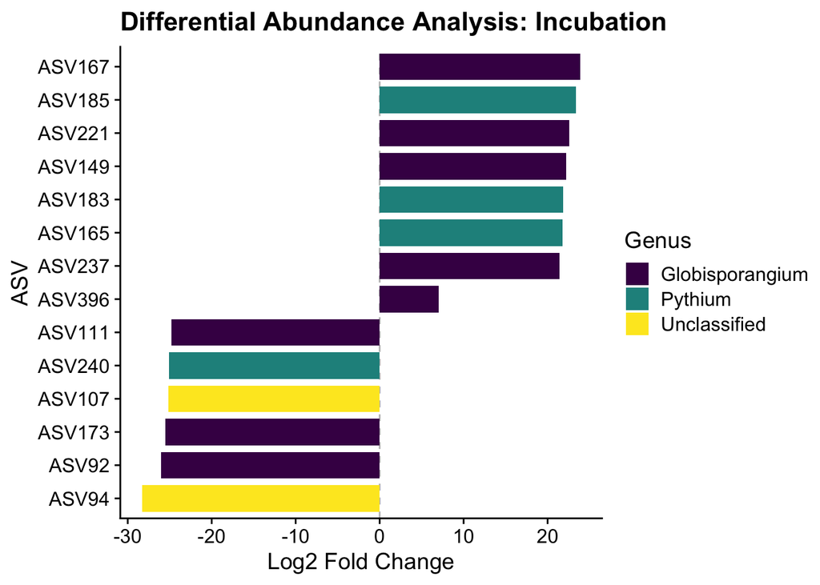

```r
# Save the plot
ggsave("Figures/RPS10/Deseq_incubation_barplot_dads_ASV.pdf", deseqplot2)
# Display the plot
print(deseqplot2)
```

### Let’s make a quick summary table of ASVs that are differentially abundant in both the Wilcoxon rank sum and DESEQ analyses-incubation

```r
# Merge the tables based on ASV
merged_table <- inner_join(dads.sig.dt, dads.wilcox.dt, by = "ASV")

# Select and rename columns in one step
final_table <- merged_table %>%
  mutate(
    deseq_pvalue = pvalue,
    deseq_padj = padj,
    wilcox_pvalue = P_Value,
    wilcox_padj = Adjusted_P_Value,
    Kingdom = Kingdom.x,
    Phylum = Phylum.x,
    Class = Class.x,
    Order = Order.x,
    Family = Family.x,
    Genus = Genus.x,
    Species = Species.x
  ) %>%
  select(
    ASV, log2FoldChange, deseq_pvalue, deseq_padj, wilcox_pvalue, wilcox_padj,
    Kingdom, Phylum, Class, Order, Family, Genus, Species
  )

# Save the final table as CSV
write.csv(final_table, "Results/RPS10/merged_deseq_incubation_wilcoxon_results.csv", row.names = FALSE)
print(paste("Number of ASVs in the final table:", nrow(final_table)))
```

```
## [1] "Number of ASVs in the final table: 0"
```

### Let’s make a plot of the merged results-incubation

```r
merged_plot <- ggplot(final_table, aes(y = reorder(ASV, log2FoldChange), x = log2FoldChange, fill = Genus)) +
  geom_vline(xintercept = 0.0, color = "gray", size = 0.5, linetype = "dashed") +
  geom_bar(stat = "identity", position = "dodge", width = 0.8) +
  scale_fill_viridis(discrete = TRUE, option = "D") +  # Color-blind friendly palette
  #scale_x_continuous(breaks = pretty_breaks(n = 10)) +  # Prettier x-axis breaks
  labs(x = "Log2 Fold Change",
       y = "ASV",
       title = "Merged DESEQ2 and Wilcoxon Rank Sum Analyses-Treatment")
  theme_minimal() +
  theme(
    axis.text.y = element_text(size = 8),
    axis.title = element_text(face = "bold"),
    legend.position = "right",
    legend.title = element_text(face = "bold"),
    plot.title = element_text(size = 16, face = "bold"),
    plot.subtitle = element_text(size = 12),
    panel.grid.major.y = element_blank(),
    panel.grid.minor = element_blank()
  )
```

[output not shown]

[output cut: 252 more lines]

[output not shown]

[figure not shown]

```r
# Save the plot
ggsave("Figures/RPS10/Deseq_merged_incubation_barplot_dads_ASV.pdf", merged_plot)
# Display the plot
print(merged_plot)
```

### Convert taxmap to phyloseq obj

```r
remove_boot_columns <- function(x) {
  x <- x[, !grepl("boot", colnames(x))]
  return(x)
}

adjust_species_names <- function(x) {
  x$Species <- sub(".*_", "", x$Species)
  return(x)
}

dads_5asv_tax <- tax_table(dads_5asv.ps) %>%
  as.data.frame() %>%
  remove_boot_columns() %>%
  adjust_species_names %>%
  as.matrix() %>%
  tax_table()

tax_table(dads_5asv.ps) <- dads_5asv_tax

obj_RPS10<-parse_phyloseq(dads_5asv.ps)
```

```
## The following 104 of 162 (64.2%) input indexes have `NA` in their classifications:
##    3, 4, 5, 10, 11, 12, 13 ... 155, 156, 157, 158, 159, 160, 161
```

```r
obj_RPS10_rarefy <-parse_phyloseq(rarefied.ps)
```

```
## The following 99 of 156 (63.5%) input indexes have `NA` in their classifications:
##    3, 4, 5, 10, 11, 12, 13 ... 147, 148, 150, 152, 153, 154, 155
```

```r
obj_RPS10$data$tax_abund <- calc_taxon_abund(obj_RPS10, data = "otu_table", cols = obj_RPS10$data$sample_data$sample_id)
```

```
## Summing per-taxon counts from 24 columns for 46 taxa
```

```r
obj_RPS10_rarefy$data$tax_abund <- calc_taxon_abund(obj_RPS10_rarefy , data = "otu_table", cols = obj_RPS10_rarefy$data$sample_data$sample_id)
```

[output not shown]

```r
obj_RPS10$data$abund_prop <- calc_obs_props(obj_RPS10, data = "otu_table", cols = obj_RPS10$data$sample_data$sample_id)
```

```
## Calculating proportions from counts for 24 columns for 162 observations.
```

```r
obj_RPS10$data$tax_prop <- calc_taxon_abund(obj_RPS10, data = "abund_prop", cols = obj_RPS10$data$sample_data$sample_id)
```

```
## Summing per-taxon counts from 24 columns for 46 taxa
```

```r
obj_RPS10$data$tax_prop$all_samples <- rowMeans(obj_RPS10$data$tax_prop[,obj_RPS10$data$sample_data$sample_id])
```

```r
set.seed(1)
obj_RPS10$data$diff_table_deseq <- metacoder::calc_diff_abund_deseq2(obj_RPS10,
                                      data = "tax_abund",
                                      cols = obj_RPS10$data$sample_data$sample_id, # What columns of sample data to
                                      groups = obj_RPS10$data$sample_data$Treatment) # What category each sample is assigned to
```

```
## -- replacing outliers and refitting for 19 genes
## -- DESeq argument 'minReplicatesForReplace' = 7
## -- original counts are preserved in counts(dds)
```

```r
obj_RPS10$data$diff_table_deseq$log2FoldChange[obj_RPS10$data$diff_table_deseq$padj > 0.05] <- 0

range(obj_RPS10$obj_RPS10$data$diff_table_deseq$padj, finite = TRUE)
```

```
## [1]  Inf -Inf
```

```r
range(obj_RPS10$data$diff_table_deseq$log2FoldChange, finite = TRUE)
```

```
## [1] -24.49382  24.90912
```

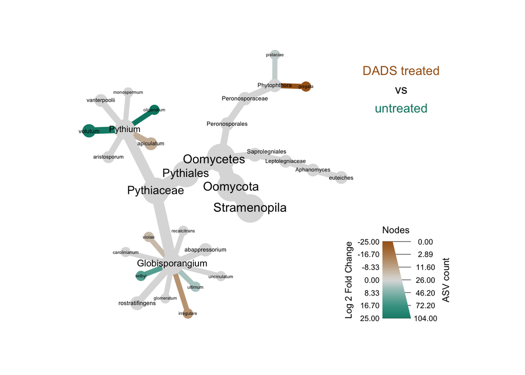

```r
obj_RPS10<- metacoder::filter_taxa(obj_RPS10, taxon_names != "None", reassign_obs = FALSE)
obj_RPS10 <- metacoder::filter_taxa(obj_RPS10, taxon_names != "", reassign_obs = FALSE)
obj_RPS10 <- metacoder::filter_taxa(obj_RPS10, taxon_names != "NA", reassign_obs = FALSE)


obj_RPS10 %>%
  metacoder::filter_taxa(taxon_ranks == "Species", supertaxa = TRUE, reassign_obs = FALSE) %>%
  remove_redundant_names() %>%
  heat_tree_matrix(data = "diff_table_deseq",
                   node_label = taxon_names,
                   node_size = n_obs, # number of OTUs
                   node_color = log2FoldChange, # difference between groups
                   node_color_trans = "linear",
                   node_color_interval = c(-25, 25), # symmetric interval
                   edge_color_interval = c(-25, 25), # symmetric interval
                   node_color_range = diverging_palette(), # diverging colors
                   node_size_axis_label = "ASV count",
                   node_color_axis_label = "Log 2 Fold Change",
                   layout = "da", initial_layout = "re",
                   key_size = 0.4,
                   output_file = "Figures/RPS10/diff_abundance_heattree_deseq_dads_RPS10.pdf") # The layout algorithm that initializes node locations
```